# Travail pratique 2 - Analytique prédictive

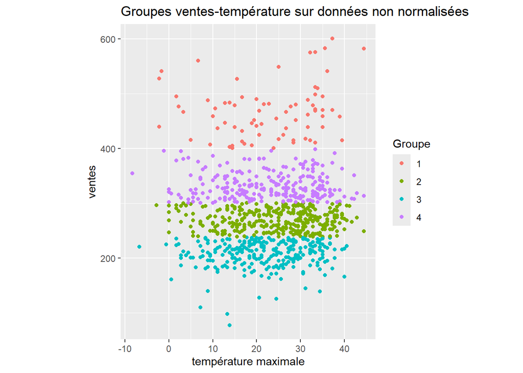

```r
ventes_meteo_cl2 %>%
  ggplot(aes(x = tmax_c,
             y = Ventes)) +
  geom_point(aes(color = factor(cluster))) +
  coord_fixed(ratio = 1/8)+
  labs(title = "Groupes ventes-température sur données non normalisées",
       color = "Groupe",
       x = "température maximale",
       y = "ventes")
```

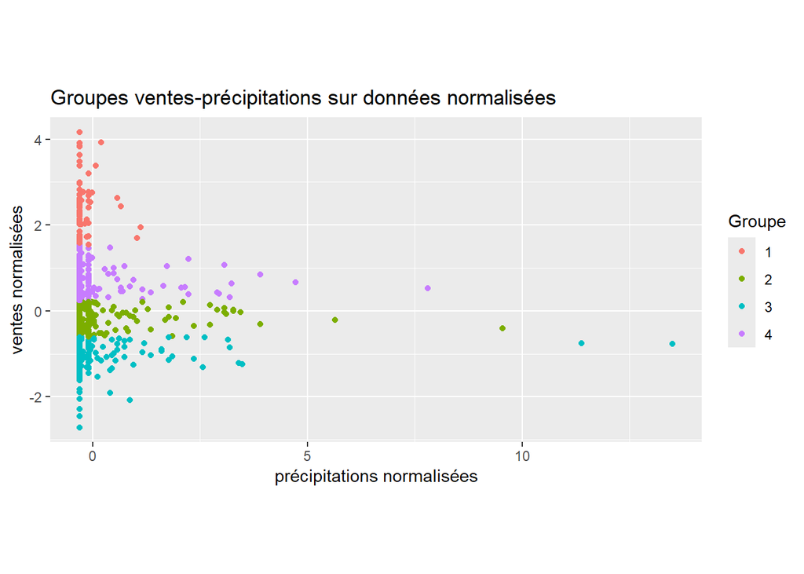

```r
ventes_meteo_cl2 %>%
  ggplot(aes(x = precip_norm,
             y = Ventes_norm)) +
  geom_point(aes(color = factor(cluster))) +
  coord_fixed() +
  labs(title = "Groupes ventes-précipitations sur données normalisées",
       color = "Groupe",
       x = "précipitations normalisées",
       y = "ventes normalisées")
```

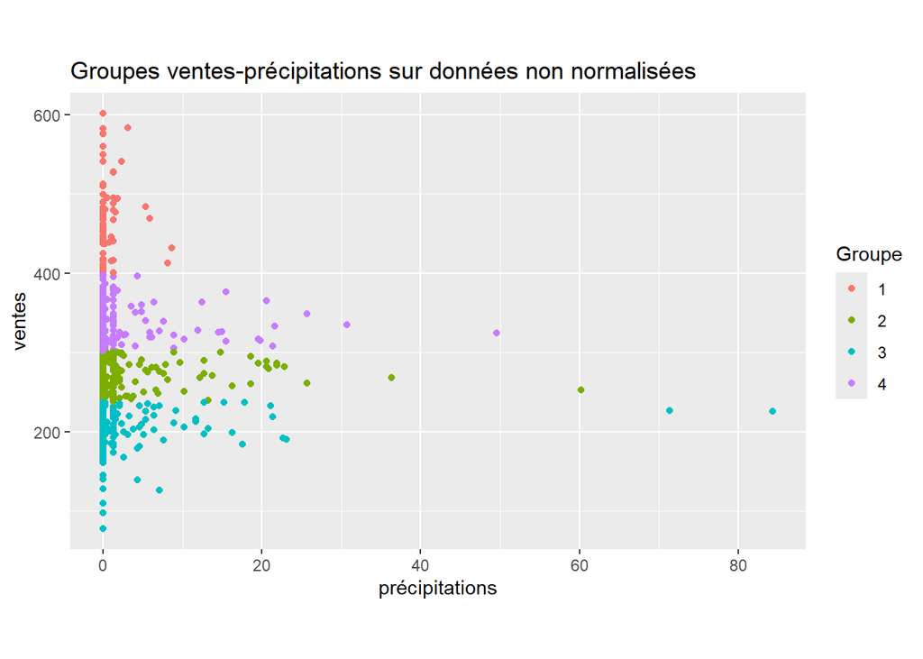

```r
ventes_meteo_cl2 %>%
  ggplot(aes(x = preciptotal_mm,
             y = Ventes)) +
  geom_point(aes(color = factor(cluster))) +
  coord_fixed(ratio = 1/10)+
  labs(title = "Groupes ventes-précipitations sur données non normalisées",
       color = "Groupe",
       x = "précipitations",
       y = "ventes")
```

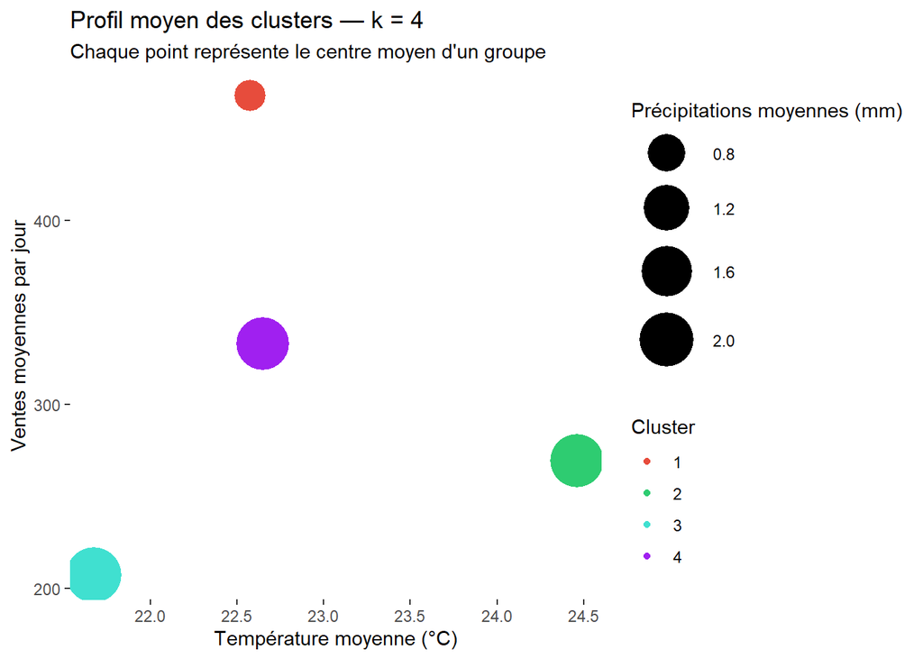

```r
#Calcul du résumé statistique pour k=4
cluster_summary1 <- ventes_meteo_cl2 %>%
  group_by(cluster) %>%
  summarise(
    n_jours = n(),
    mean_Ventes = mean(Ventes),
    sd_Ventes = sd(Ventes),
    mean_tmax = mean(tmax_c),
    mean_precip = mean(preciptotal_mm),
    .groups = "drop"
  )

#visualisation des groupes de façon générale
cluster_summary1 %>%
  ggplot(aes(x = mean_tmax,
             y = mean_Ventes,
             size = mean_precip,
             color = factor(cluster))) +
   geom_point(alpha = 1, shape = 16) +
   scale_size_continuous(
    name = "Précipitations moyennes (mm)",
    range = c(8, 14)) +
      scale_color_manual(
    values = c("1" = "#E74C3C",
               "2" = "#2ECC71",
               "3" = "turquoise",
               "4" = "purple")
  ) +
  labs(
    title = paste("Profil moyen des clusters — k = 4"),
    subtitle = "Chaque point représente le centre moyen d'un groupe",
    x = "Température moyenne (°C)",
    y = "Ventes moyennes par jour",
    color = "Cluster") +
  theme(panel.background = element_blank())
```

```r
# 9. Résumé statistique détaillé
print(cluster_summary1)
```

```
## # A tibble: 4 × 6
##   cluster n_jours mean_Ventes sd_Ventes mean_tmax mean_precip
##     <int>   <int>       <dbl>     <dbl>     <dbl>       <dbl>
## 1       1      73        468.      49.5      22.6       0.710
## 2       2     335        270.      17.9      24.5       1.88
## 3       3     262        207.      24.4      21.7       2.11
## 4       4     241        333.      24.0      22.7       1.84
```

Voici l’analyse avec 3 regroupements cette fois-ci.

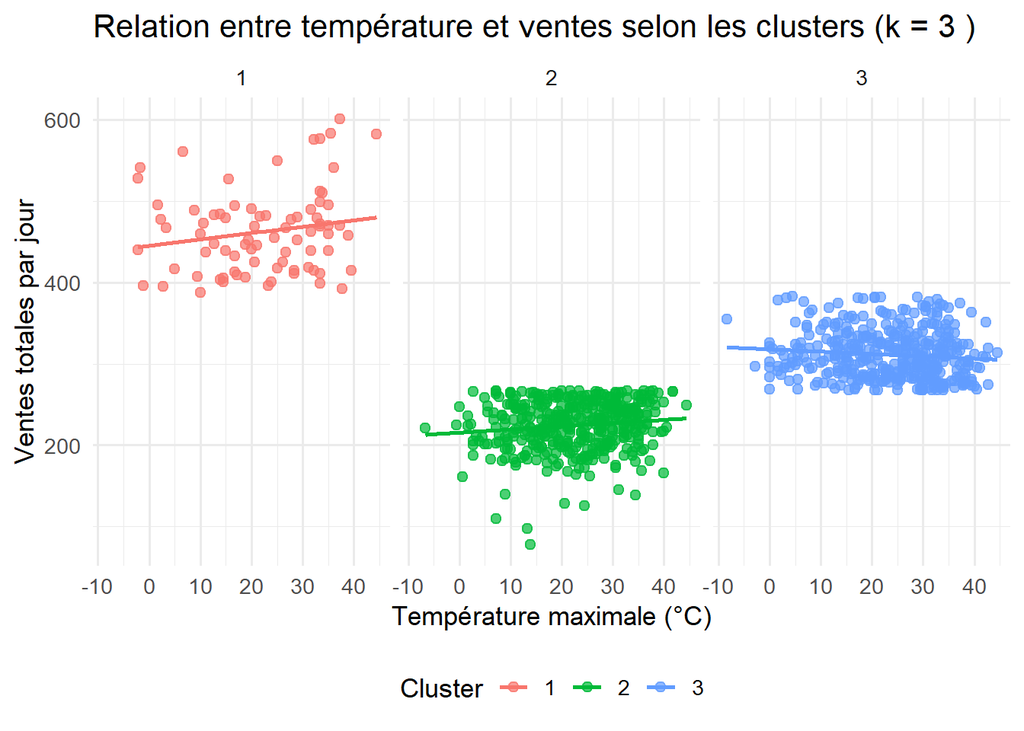

```r
# ANALYSE K-MEANS

# 1. Choix du nombre de clusters
k_choice <- 3

# 2. Exécution du k-means
set.seed(2342423)
kmeans_res <- kmeans(ventes_meteo_cl, centers = k_choice)

# 3. Ajout des clusters au jeu de données d'origine
data_clusters <- ventes_meteo_cl %>%
  mutate(
    cluster = factor(kmeans_res$cluster),
    tmax_scaled = scale(tmax_c)[, 1],
    precip_scaled = scale(preciptotal_mm)[, 1]
  )

# 4. Calcul du résumé statistique pour k=3

cluster_summary <- data_clusters %>%
  group_by(cluster) %>%
  summarise(
    n_jours = n(),
    mean_Ventes = mean(Ventes),
    sd_Ventes = sd(Ventes),
    mean_tmax = mean(tmax_c),
    mean_precip = mean(preciptotal_mm),
    .groups = "drop"
  )

# 5. Calcul des centroïdes sur l'échelle originale
centroids_original <- as_tibble(kmeans_res$centers) %>%
  mutate(cluster = factor(1:k_choice))

# 6. Visualisation 1 : Corrélation entre Température et Ventes
ggplot(data_clusters, aes(x = tmax_c, y = Ventes, color = cluster)) +
  geom_point(alpha = 0.7, size = 2) +
  geom_smooth(method = "lm", se = FALSE, linewidth = 1) +  # linewidth au lieu de size
  facet_wrap(~ cluster, ncol = 3) +
  labs(
    title = paste("Relation entre température et ventes selon les clusters (k =", k_choice, ")"),
    x = "Température maximale (°C)",
    y = "Ventes totales par jour",
    color = "Cluster"
  ) +
  theme_minimal(base_size = 13) +
  theme(legend.position = "bottom")
```

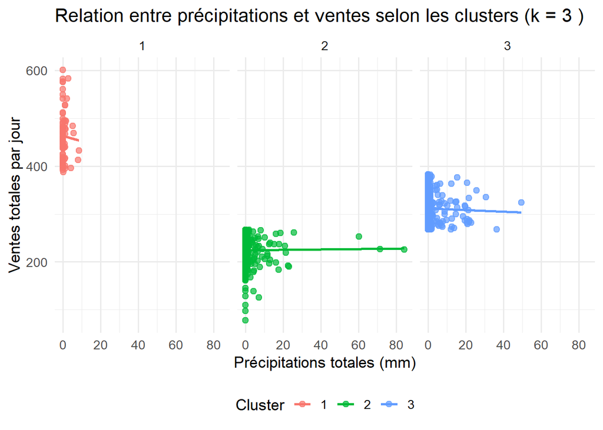

```r
# 7. Visualisation 2 : Corrélation entre Précipitations et Ventes
ggplot(data_clusters, aes(x = preciptotal_mm, y = Ventes, color = cluster)) +
  geom_point(alpha = 0.7, size = 2) +
  geom_smooth(method = "lm", se = FALSE, linewidth = 1) +  # linewidth au lieu de size
  facet_wrap(~ cluster, ncol = 3) +
  labs(
    title = paste("Relation entre précipitations et ventes selon les clusters (k =", k_choice, ")"),
    x = "Précipitations totales (mm)",
    y = "Ventes totales par jour",
    color = "Cluster"
  ) +
  theme_minimal(base_size = 13) +
  theme(legend.position = "bottom")
```

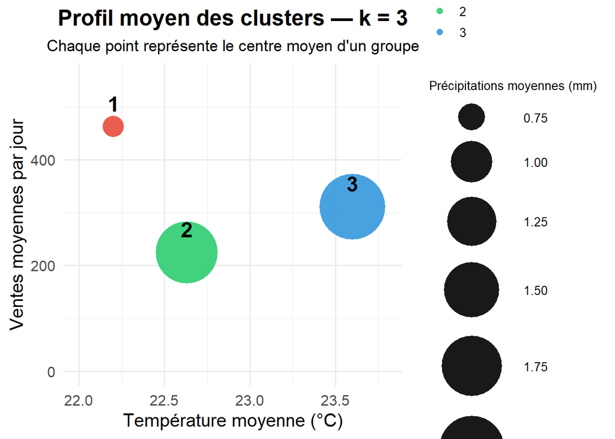

```r
# 8. Visualisation 3 : Profil moyen des clusters
ggplot(cluster_summary,
       aes(x = mean_tmax, y = mean_Ventes,
           size = mean_precip, color = cluster)) +

  # Points pleins colorés (plus visibles)
  geom_point(alpha = 0.9, shape = 16) +

  # Étiquettes des clusters (bien visibles, légèrement décalées)
  geom_text(aes(label = cluster),
            vjust = -1, hjust = 0.5, size = 6,
            fontface = "bold", color = "black", show.legend = FALSE) +

  # Taille des points amplifiée pour distinguer le cluster 1
  scale_size_continuous(
    name = "Précipitations moyennes (mm)",
    range = c(8, 25)
  ) +

  # Palette manuelle contrastée
  scale_color_manual(
    values = c("1" = "#E74C3C",  # rouge vif
               "2" = "#2ECC71",  # vert clair
               "3" = "#3498DB")  # bleu moyen
  ) +

  labs(
    title = paste("Profil moyen des clusters — k =", k_choice),
    subtitle = "Chaque point représente le centre moyen d'un groupe",
    x = "Température moyenne (°C)",
    y = "Ventes moyennes par jour",
    color = "Cluster"
  ) +

  # Étendre l'échelle pour ne rien couper
  coord_cartesian(
    ylim = c(0, max(cluster_summary$mean_Ventes) * 1.2),
    xlim = c(min(cluster_summary$mean_tmax) - 0.2, max(cluster_summary$mean_tmax) + 0.2)
  ) +

  theme_minimal(base_size = 15) +
  theme(
    plot.title = element_text(face = "bold", size = 18, hjust = 0.5),
    plot.subtitle = element_text(size = 13, hjust = 0.5),
    legend.position = "right",
    legend.title = element_text(size = 10),
    legend.text = element_text(size = 10)
  )
```

```r
# 9. Résumé statistique détaillé
print(cluster_summary)
```

```
## # A tibble: 3 × 6
##   cluster n_jours mean_Ventes sd_Ventes mean_tmax mean_precip
##   <fct>     <int>       <dbl>     <dbl>     <dbl>       <dbl>
## 1 1            79        462.      51.5      22.2       0.730
## 2 2           422        225.      30.1      22.6       1.85
## 3 3           410        311.      29.5      23.6       2.05
```

## Qualité des regroupements

Vérifier la qualité des groupes lorsqu’on utilise 4 groupes pour faire les regroupements :

```r
#betwenss doit être haut, relativement à withinss
cl$betweenss
```

```
## [1] 4679890
```

```r
#withinss doit être bas, relativement à betweenss
cl$withinss
```

```
## [1] 186241.6 151317.2 193913.0 173637.2
```

```r
#ratio doit se rapprocher de 1, avec un petit nombre de groupes
cl$betweenss / cl$totss
```

```
## [1] 0.8690605
```

Vérifier la qualité des groupes lorsqu’on utilise 3 groupes pour faire les regroupements :

```r
kmeans_res$betweenss
```

```
## [1] 4312127
```

```r
kmeans_res$withinss
```

```
## [1] 218037.3 441727.3 413107.3
```

```r
kmeans_res$betweenss / kmeans_res$totss
```

```
## [1] 0.8007665
```

Lorsque le ratio betweenss/totss se rapproche de 1, nous avons des groupes de bonne qualité. C’est la mesure du pourcentage de la variance qui est expliquée par les groupes.  
Selon notre analyse, 4 groupes semblent avoir une meilleur performance que 3 groupes. 86.90% de la variance peut être expliquée avec ces 4 groupes. De plus, un betweens haut et un withinss bas sont souhaitables. Le regroupement fait avec 4 groupes est également mieux pour ces paramètres.

# Conclusion

Avant de former les groupes, nous avions 2 hypothèses: - Il ne semble pas avoir de lien entre la température maximale et le nombre de ventes - Les journées qui ont beaucoup plus de précipitations ont moins de ventes

Grolemund, Garrett, and Hadley Wickham. 2011. “Dates and Times Made Easy with lubridate.” *Journal of Statistical Software* 40 (3): 1–25. https://www.jstatsoft.org/v40/i03/.

Motl, Jan, and Oliver Schulte. 2015. “The CTU Prague Relational Learning Repository.” *arXiv Preprint arXiv:1511.03086*.

R Core Team. 2025. *R: A Language and Environment for Statistical Computing*. Vienna, Austria: R Foundation for Statistical Computing. https://www.R-project.org/.

Schloerke, Barret, Di Cook, Joseph Larmarange, Francois Briatte, Moritz Marbach, Edwin Thoen, Amos Elberg, and Jason Crowley. 2025. *GGally: Extension to ’Ggplot2’*. https://doi.org/10.32614/CRAN.package.GGally.

Wickham, Hadley. 2023. *Modelr: Modelling Functions That Work with the Pipe*. https://doi.org/10.32614/CRAN.package.modelr.

Wickham, Hadley, Mara Averick, Jennifer Bryan, Winston Chang, Lucy D’Agostino McGowan, Romain François, Garrett Grolemund, et al. 2019. “Welcome to the tidyverse.” *Journal of Open Source Software* 4 (43): 1686. https://doi.org/10.21105/joss.01686.